# Ford Gobike Data Exploration

## Preliminary Wrangling

> This data set includes information about individual rides made in a bike-sharing system covering the greater San Francisco Bay area in 2019.

```python
# import all packages and set plots to be embedded inline
import numpy as np
import pandas as pd
import matplotlib.pyplot as plt
import seaborn as sns

# allows us to view our graphs in jupyter notebook.
%matplotlib inline
```

```python
# load in dataset into pandas dataframe
df = pd.read_csv('201902-fordgobike-tripdata.csv')
```

```python
# display first 5 rows dataframe
df.head()
```

|  | duration_sec | start_time | end_time | start_station_id | start_station_name | start_station_latitude | start_station_longitude | end_station_id | end_station_name | end_station_latitude | end_station_longitude | bike_id | user_type | member_birth_year | member_gender | bike_share_for_all_trip |
| --- | --- | --- | --- | --- | --- | --- | --- | --- | --- | --- | --- | --- | --- | --- | --- | --- |
| 0 | 52185 | 2019-02-28 17:32:10.1450 | 2019-03-01 08:01:55.9750 | 21.0 | Montgomery St BART Station (Market St at 2nd St) | 37.789625 | -122.400811 | 13.0 | Commercial St at Montgomery St | 37.794231 | -122.402923 | 4902 | Customer | 1984.0 | Male | No |
| 1 | 42521 | 2019-02-28 18:53:21.7890 | 2019-03-01 06:42:03.0560 | 23.0 | The Embarcadero at Steuart St | 37.791464 | -122.391034 | 81.0 | Berry St at 4th St | 37.775880 | -122.393170 | 2535 | Customer | NaN | NaN | No |
| 2 | 61854 | 2019-02-28 12:13:13.2180 | 2019-03-01 05:24:08.1460 | 86.0 | Market St at Dolores St | 37.769305 | -122.426826 | 3.0 | Powell St BART Station (Market St at 4th St) | 37.786375 | -122.404904 | 5905 | Customer | 1972.0 | Male | No |
| 3 | 36490 | 2019-02-28 17:54:26.0100 | 2019-03-01 04:02:36.8420 | 375.0 | Grove St at Masonic Ave | 37.774836 | -122.446546 | 70.0 | Central Ave at Fell St | 37.773311 | -122.444293 | 6638 | Subscriber | 1989.0 | Other | No |
| 4 | 1585 | 2019-02-28 23:54:18.5490 | 2019-03-01 00:20:44.0740 | 7.0 | Frank H Ogawa Plaza | 37.804562 | -122.271738 | 222.0 | 10th Ave at E 15th St | 37.792714 | -122.248780 | 4898 | Subscriber | 1974.0 | Male | Yes |

```python
# how many rows and columns
df.shape
```

```
(183412, 16)
```

```python
# overview of the composition of data
df.info()
```

```
<class 'pandas.core.frame.DataFrame'>
RangeIndex: 183412 entries, 0 to 183411
Data columns (total 16 columns):
 #   Column                   Non-Null Count   Dtype
---  ------                   --------------   -----
 0   duration_sec             183412 non-null  int64
 1   start_time               183412 non-null  object
 2   end_time                 183412 non-null  object
 3   start_station_id         183215 non-null  float64
 4   start_station_name       183215 non-null  object
 5   start_station_latitude   183412 non-null  float64
 6   start_station_longitude  183412 non-null  float64
 7   end_station_id           183215 non-null  float64
 8   end_station_name         183215 non-null  object
 9   end_station_latitude     183412 non-null  float64
 10  end_station_longitude    183412 non-null  float64
 11  bike_id                  183412 non-null  int64
 12  user_type                183412 non-null  object
 13  member_birth_year        175147 non-null  float64
 14  member_gender            175147 non-null  object
 15  bike_share_for_all_trip  183412 non-null  object
dtypes: float64(7), int64(2), object(7)
memory usage: 22.4+ MB
```

```python
#  drop unwanted columns We drop 'NaN' values

df.drop(['start_station_latitude','start_station_longitude', 'end_station_latitude', 'end_station_longitude'], axis=1, inplace=True)

# test that column drop is successful
df.info()
```

```
<class 'pandas.core.frame.DataFrame'>
RangeIndex: 183412 entries, 0 to 183411
Data columns (total 12 columns):
 #   Column                   Non-Null Count   Dtype
---  ------                   --------------   -----
 0   duration_sec             183412 non-null  int64
 1   start_time               183412 non-null  object
 2   end_time                 183412 non-null  object
 3   start_station_id         183215 non-null  float64
 4   start_station_name       183215 non-null  object
 5   end_station_id           183215 non-null  float64
 6   end_station_name         183215 non-null  object
 7   bike_id                  183412 non-null  int64
 8   user_type                183412 non-null  object
 9   member_birth_year        175147 non-null  float64
 10  member_gender            175147 non-null  object
 11  bike_share_for_all_trip  183412 non-null  object
dtypes: float64(3), int64(2), object(7)
memory usage: 16.8+ MB
```

```python
# checking if there are duplicates
sum(df.duplicated())
```

```
0
```

```python
# Finding how many bikes there are in this dataset
df.bike_id.nunique()
```

```
4646
```

```python
# changing data type of start_time and end_time to datetime.
df.start_time = pd.to_datetime(df.start_time)
df.end_time = pd.to_datetime(df.end_time)
```

```python
# new columns from start_time
df['start_month'] = df.start_time.dt.month
df['start_weekday'] = df.start_time.dt.weekday
df['start_hour'] = df.start_time.dt.hour

# convert seconds to minutes
df['duration_minutes'] = df['duration_sec']/60
```

```python
# test for datatype change and the addition of 4 new columns
df.info()
```

```
<class 'pandas.core.frame.DataFrame'>
RangeIndex: 183412 entries, 0 to 183411
Data columns (total 16 columns):
 #   Column                   Non-Null Count   Dtype
---  ------                   --------------   -----
 0   duration_sec             183412 non-null  int64
 1   start_time               183412 non-null  datetime64[ns]
 2   end_time                 183412 non-null  datetime64[ns]
 3   start_station_id         183215 non-null  float64
 4   start_station_name       183215 non-null  object
 5   end_station_id           183215 non-null  float64
 6   end_station_name         183215 non-null  object
 7   bike_id                  183412 non-null  int64
 8   user_type                183412 non-null  object
 9   member_birth_year        175147 non-null  float64
 10  member_gender            175147 non-null  object
 11  bike_share_for_all_trip  183412 non-null  object
 12  start_month              183412 non-null  int64
 13  start_weekday            183412 non-null  int64
 14  start_hour               183412 non-null  int64
 15  duration_minutes         183412 non-null  float64
dtypes: datetime64[ns](2), float64(4), int64(5), object(5)
memory usage: 22.4+ MB
```

```python
# changing datatype to boolean
df.bike_share_for_all_trip = (df.bike_share_for_all_trip == 'Yes')
```

```python
# test to confirm change to boolean
df.info()
```

```
<class 'pandas.core.frame.DataFrame'>
RangeIndex: 183412 entries, 0 to 183411
Data columns (total 16 columns):
 #   Column                   Non-Null Count   Dtype
---  ------                   --------------   -----
 0   duration_sec             183412 non-null  int64
 1   start_time               183412 non-null  datetime64[ns]
 2   end_time                 183412 non-null  datetime64[ns]
 3   start_station_id         183215 non-null  float64
 4   start_station_name       183215 non-null  object
 5   end_station_id           183215 non-null  float64
 6   end_station_name         183215 non-null  object
 7   bike_id                  183412 non-null  int64
 8   user_type                183412 non-null  object
 9   member_birth_year        175147 non-null  float64
 10  member_gender            175147 non-null  object
 11  bike_share_for_all_trip  183412 non-null  bool
 12  start_month              183412 non-null  int64
 13  start_weekday            183412 non-null  int64
 14  start_hour               183412 non-null  int64
 15  duration_minutes         183412 non-null  float64
dtypes: bool(1), datetime64[ns](2), float64(4), int64(5), object(4)
memory usage: 21.2+ MB
```

```python
# descriptive statistics for numeric variables
df.describe()
```

|  | duration_sec | start_station_id | end_station_id | bike_id | member_birth_year | start_month | start_weekday | start_hour | duration_minutes |
| --- | --- | --- | --- | --- | --- | --- | --- | --- | --- |
| count | 183412.000000 | 183215.000000 | 183215.000000 | 183412.000000 | 175147.000000 | 183412.0 | 183412.000000 | 183412.000000 | 183412.000000 |
| mean | 726.078435 | 138.590427 | 136.249123 | 4472.906375 | 1984.806437 | 2.0 | 2.632178 | 13.458421 | 12.101307 |
| std | 1794.389780 | 111.778864 | 111.515131 | 1664.383394 | 10.116689 | 0.0 | 1.814786 | 4.724978 | 29.906496 |
| min | 61.000000 | 3.000000 | 3.000000 | 11.000000 | 1878.000000 | 2.0 | 0.000000 | 0.000000 | 1.016667 |
| 25% | 325.000000 | 47.000000 | 44.000000 | 3777.000000 | 1980.000000 | 2.0 | 1.000000 | 9.000000 | 5.416667 |
| 50% | 514.000000 | 104.000000 | 100.000000 | 4958.000000 | 1987.000000 | 2.0 | 3.000000 | 14.000000 | 8.566667 |
| 75% | 796.000000 | 239.000000 | 235.000000 | 5502.000000 | 1992.000000 | 2.0 | 4.000000 | 17.000000 | 13.266667 |
| max | 85444.000000 | 398.000000 | 398.000000 | 6645.000000 | 2001.000000 | 2.0 | 6.000000 | 23.000000 | 1424.066667 |

There are 183412 fordgobike trips in the cleaned dataset with 16 specifications or columns (duration_sec, start_time, end_time, start_station_id, start_station_name, end_station_id, end_station_name, bike_id, user_type, member_birth_year, member_gender, bike_share_for_all_trip duration_minutes, start_month, start_weekday, start_hour). Out of 16 specifications 9 are numerical(int or float), 2 are datetime, 4 are object type and 1 is boolean type.

```python
df.sample(100)
```

|  | duration_sec | start_time | end_time | start_station_id | start_station_name | end_station_id | end_station_name | bike_id | user_type | member_birth_year | member_gender | bike_share_for_all_trip | start_month | start_weekday | start_hour | duration_minutes |
| --- | --- | --- | --- | --- | --- | --- | --- | --- | --- | --- | --- | --- | --- | --- | --- | --- |
| 102857 | 308 | 2019-02-14 15:39:27.621 | 2019-02-14 15:44:36.271 | 245.0 | Downtown Berkeley BART | 256.0 | Hearst Ave at Euclid Ave | 6645 | Subscriber | 1985.0 | Male | True | 2 | 3 | 15 | 5.133333 |
| 25552 | 876 | 2019-02-25 16:37:21.577 | 2019-02-25 16:51:57.585 | 19.0 | Post St at Kearny St | 112.0 | Harrison St at 17th St | 5388 | Subscriber | 1993.0 | Male | False | 2 | 0 | 16 | 14.600000 |
| 83430 | 519 | 2019-02-18 00:18:18.981 | 2019-02-18 00:26:58.039 | 60.0 | 8th St at Ringold St | 136.0 | 23rd St at San Bruno Ave | 4602 | Customer | NaN | NaN | False | 2 | 0 | 0 | 8.650000 |
| 29373 | 793 | 2019-02-25 07:26:00.808 | 2019-02-25 07:39:14.736 | 15.0 | San Francisco Ferry Building (Harry Bridges Pl... | 126.0 | Esprit Park | 5752 | Subscriber | 1985.0 | Male | False | 2 | 0 | 7 | 13.216667 |
| 7106 | 321 | 2019-02-28 09:23:52.504 | 2019-02-28 09:29:13.670 | 6.0 | The Embarcadero at Sansome St | 14.0 | Clay St at Battery St | 2630 | Subscriber | 1982.0 | Male | False | 2 | 3 | 9 | 5.350000 |
| ... | ... | ... | ... | ... | ... | ... | ... | ... | ... | ... | ... | ... | ... | ... | ... | ... |
| 102740 | 778 | 2019-02-14 15:51:07.730 | 2019-02-14 16:04:06.563 | 239.0 | Bancroft Way at Telegraph Ave | 239.0 | Bancroft Way at Telegraph Ave | 6408 | Subscriber | 1998.0 | Female | True | 2 | 3 | 15 | 12.966667 |
| 158840 | 413 | 2019-02-05 18:37:29.119 | 2019-02-05 18:44:22.838 | 54.0 | Alamo Square (Steiner St at Fulton St) | 84.0 | Duboce Park | 4799 | Subscriber | 1969.0 | Female | False | 2 | 1 | 18 | 6.883333 |
| 115419 | 1069 | 2019-02-12 08:31:47.426 | 2019-02-12 08:49:37.142 | 123.0 | Folsom St at 19th St | 42.0 | San Francisco City Hall (Polk St at Grove St) | 1649 | Subscriber | 1982.0 | Female | False | 2 | 1 | 8 | 17.816667 |
| 36759 | 562 | 2019-02-23 15:24:45.947 | 2019-02-23 15:34:08.232 | 120.0 | Mission Dolores Park | 58.0 | Market St at 10th St | 5916 | Subscriber | 1996.0 | Male | False | 2 | 5 | 15 | 9.366667 |
| 161703 | 1094 | 2019-02-05 13:50:29.947 | 2019-02-05 14:08:44.943 | 86.0 | Market St at Dolores St | 70.0 | Central Ave at Fell St | 4931 | Subscriber | 1990.0 | Other | False | 2 | 1 | 13 | 18.233333 |

100 rows × 16 columns

### What are the main feature(s) of interest in the dataset?

I am interested in the the features that best predict average bike trip. These are age, gender and user type.

### What features in the dataset do you think will help support your investigation into your feature(s) of interest?

I expect that the trip duration is determined from the values in our column 'duration_min'. The subscriber anc customer values from 'user_type' will tell the number of users.

## Univariate Exploration

I'll start by looking at the duration_minutes as the main variable of interest. To determine the average bike trips as a unit of time.

### Average bike trip duration

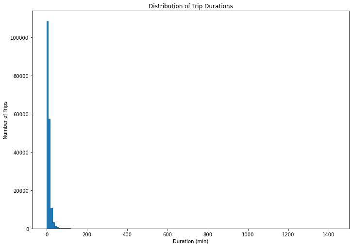

```python
# histogram plot displaying bike trips in minutes
binsize = 10
bins = np.arange(0, df['duration_minutes'].max()+binsize, binsize)

plt.figure(figsize=[11.69, 8.27])
plt.hist(data = df, x = 'duration_minutes', bins = bins)
plt.title('Distribution of Trip Durations')
plt.xlabel('Duration (min)')
plt.ylabel('Number of Trips')
plt.show()
```

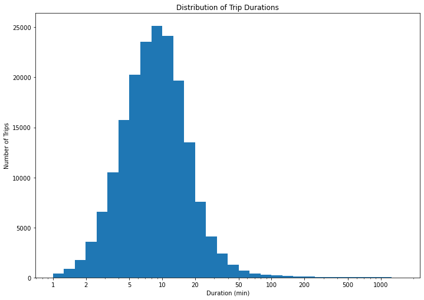

```python
# logarthmic scale transformation on a histogram
# there's a long tail in the distribution, so let's put it on a log scale instead
log_binsize = 0.1
log_bins = 10 ** np.arange(0.0, np.log10(df['duration_minutes'].max()) + log_binsize, log_binsize)

plt.figure(figsize=[11.69, 8.27])
plt.hist(data = df, x = 'duration_minutes', bins = log_bins)
plt.title('Distribution of Trip Durations')
plt.xlabel('Duration (min)')
plt.ylabel('Number of Trips')
plt.xscale('log')
tick_locs = [1, 2, 5, 10, 20, 50, 100, 200, 500, 1000]
plt.xticks(tick_locs, tick_locs)
plt.show()
```

```python
df.duration_minutes.describe()
```

```
count    183412.000000
mean         12.101307
std          29.906496
min           1.016667
25%           5.416667
50%           8.566667
75%          13.266667
max        1424.066667
Name: duration_minutes, dtype: float64
```

**User Type Key** Customer = 24-hour pass or 3-day pass user Subscriber = Annual Member

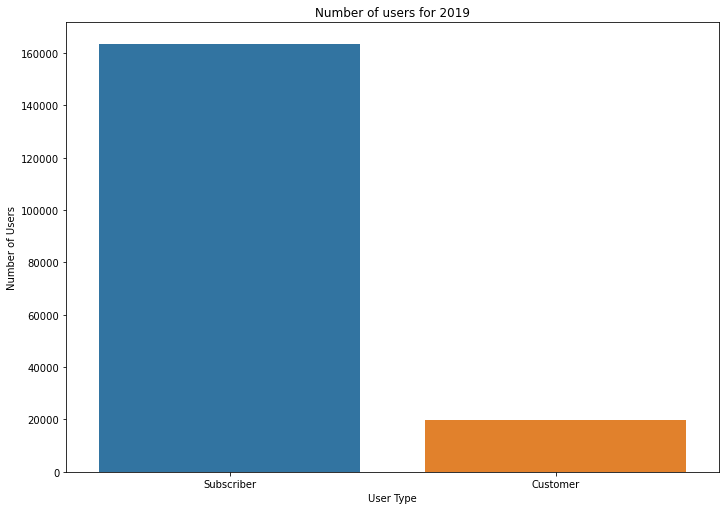

```python
# plot a bar chart
plt.figure(figsize=[11.69, 8.27])
user_category = df['user_type'].value_counts().index
sns.countplot(data = df, x = 'user_type', order = user_category)
plt.title('Number of users for 2019')
plt.xlabel('User Type')
plt.ylabel('Number of Users')
plt.show()
```

The bar chart shows over 160,000 subscribing users and 20,000 customers. I f we consider price or value for money then it does mae sense that the majority of users subsrcribe instead of just a single or 3 day pass. You get access to un limited 45 minutes rides which works out much better than single or 3 day passes.

...or using a pie chat

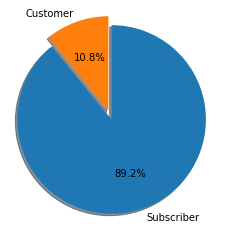

```python
# plot a pie chart
user_category = df['user_type'].value_counts()
plt.pie(user_category, explode =  (0, 0.1), labels = user_category.index, shadow = True, startangle = 90,
        counterclock = False, autopct='%1.1f%%');
plt.axis('square')
plt.show()
```

Most users are actually subscribers (89.2% of total users) who are using the program more than actual customers who represents only 10.8% of total users.

```python
# labels to use in plots
month_labels = ['Jan', 'Feb', 'Mar', 'Apr', 'May', 'Jun', 'Jul', 'Aug', 'Sep', 'Oct', 'Nov', 'Dec']
weekday_labels = ['Mon', 'Tue', 'Wed', 'Thu', 'Fri', 'Sat', 'Sun']
```

## Daily Ride Usage

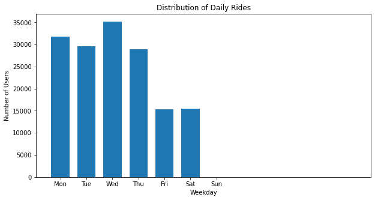

```python
# plot a histogram with gaps between bars
bin_edges = np.arange(0.5, 12.5 + 1, 1)
plt.figure(figsize=[10,5])
plt.hist(data = df, x = 'start_weekday', bins = bin_edges, rwidth = 0.7)
plt.xticks(np.arange(1, 7 + 1, 1),weekday_labels)
plt.xlabel('start_weekday')
plt.title('Distribution of Daily Rides')
plt.xlabel('Weekday')
plt.ylabel('Number of Users')
plt.show()
```

```python
df.start_weekday.mean
```

[output not shown]

## What is the Gender Distribution?

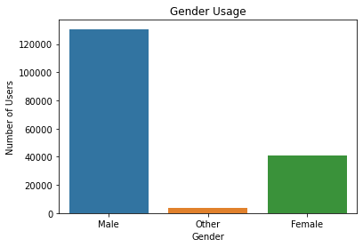

```python
# barplot of gender usage
sns.countplot(data = df, x = 'member_gender')
plt.title('Gender Usage')
plt.xlabel('Gender')
plt.ylabel('Number of Users')
```

Males use the bike service overwhelmily more than females and other genders. Over 120,000 males used the service in 2019.

## What is the Age Distribution?

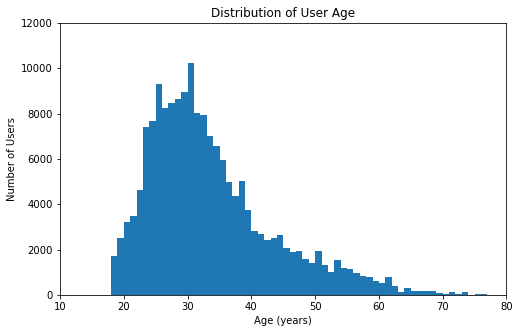

```python
# Plotting age distribution derived from member's birth year.
binsize = 1
bins = np.arange(0, df['member_birth_year'].astype(float).max()+binsize, binsize)

plt.figure(figsize=[8, 5])
plt.hist(data = df.dropna(), x = 'member_birth_year', bins = bins)
plt.axis([1939, 2009, 0, 12000])
plt.xticks([1939, 1949, 1959, 1969, 1979, 1989, 1999, 2009], [(2019-1939), (2019-1949), (2019-1959), (2019-1969), (2019-1979), (2019-1989), (2019-1999), (2019-2009)])
plt.gca().invert_xaxis()
plt.title('Distribution of User Age')
plt.xlabel('Age (years)')
plt.ylabel('Number of Users')
plt.show()
```

Most users are between the age 25 and 35. There is a steadly decline in usage from age 35 and up.

```python
df.member_birth_year.describe()
```

```
count    175147.000000
mean       1984.806437
std          10.116689
min        1878.000000
25%        1980.000000
50%        1987.000000
75%        1992.000000
max        2001.000000
Name: member_birth_year, dtype: float64
```

Males are outpacing the female and other genders in bike ride usage. Male represents over 120,000 with females representing a third of that amount.

## Bivariate Exploration

To start off with, I want to look at the pairwise correlations present between features in the data.

## Trip Duration and Age

```python
numeric_vars = ['duration_minutes', 'member_birth_year']
```

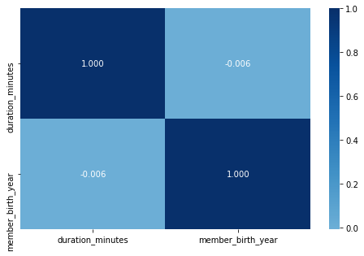

```python
# heatmap to show relationship between variables
plt.figure(figsize = [8, 5])
sns.heatmap(df[numeric_vars].corr(), annot = True, fmt = '.3f',cmap = 'Blues', center = 0)
plt.show()
```

...another look

```python
from datetime import datetime
df['age'] = datetime.now().year - df.member_birth_year
```

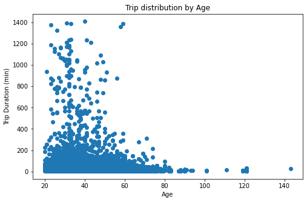

```python
# scatter charts showing distribution between age and trip duration
plt.figure(figsize=[8,5])
plt.scatter(data = df, x = 'age', y ='duration_minutes', alpha= None)
plt.title('Trip distribution by Age')
plt.xlabel('Age')
plt.ylabel('Trip Duration (min)')
plt.show()
```

## Trip Duration and Gender

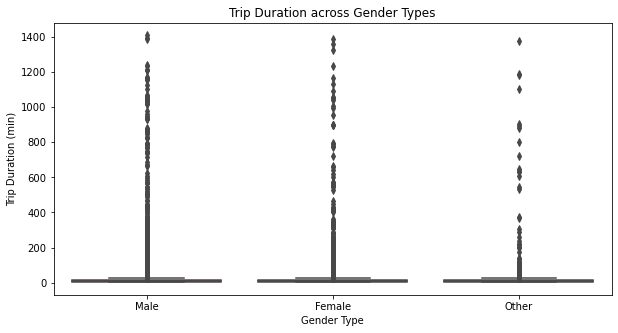

```python
# https://seaborn.pydata.org/generated/seaborn.boxplot.html
# A box plot showing comparisons between quatitative and categorical variables
import seaborn as sns
plt.figure(figsize = [10, 5])
sns.boxplot(x='member_gender', y='duration_minutes', data = df, palette = 'Set1', order=['Male', 'Female', 'Other'])
plt.title('Trip Duration across Gender Types')
plt.xlabel('Gender Type')
plt.ylabel('Trip Duration (min)')
plt.show()
```

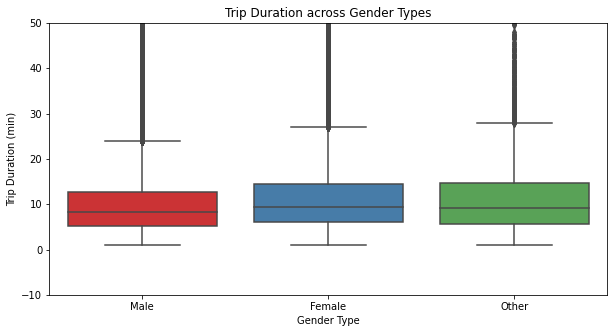

```python
# https://seaborn.pydata.org/generated/seaborn.boxplot.html
# A box plot showing comparisons between quatitative and categorical variables
import seaborn as sns
plt.figure(figsize = [10, 5])
sns.boxplot(x='member_gender', y='duration_minutes', data = df, palette ='Set1', order=['Male', 'Female', 'Other'])
plt.ylim(-10, 50)
plt.title('Trip Duration across Gender Types')
plt.xlabel('Gender Type')
plt.ylabel('Trip Duration (min)')
plt.show()
```

Trimming the trip duration y axis values is best so we can better view the box plot. Trimmed to 50 minutes. The boxplot does show that female and other gender have a higher trip duration than males.

## Trip Duration and User Type

```python
# customer and subscriber from user_type
customer_user = df['user_type']=='Customer'
subscriber_user = df['user_type']=='Subscriber'
```

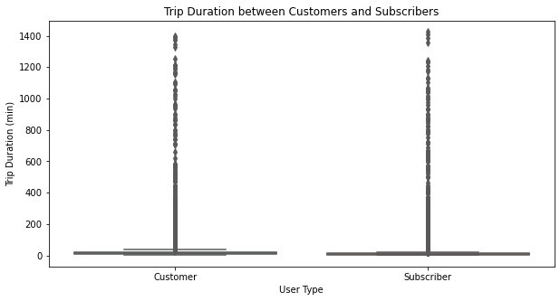

```python
# https://seaborn.pydata.org/generated/seaborn.boxplot.html
# A box plot showing comparisons between quatitative and categorical variables
import seaborn as sns
plt.figure(figsize = [10, 5])
sns.boxplot(x='user_type', y='duration_minutes', data = df, palette ='Set2')
plt.title('Trip Duration between Customers and Subscribers')
plt.xlabel('User Type')
plt.ylabel('Trip Duration (min)')
plt.show()
```

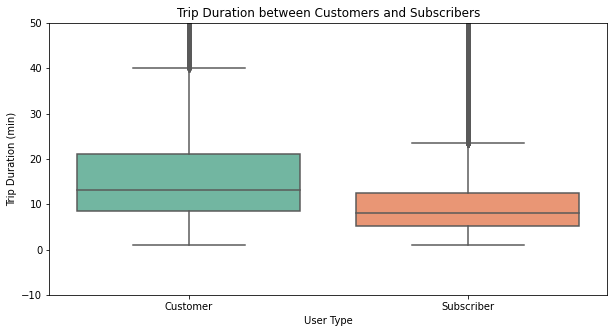

```python
# https://seaborn.pydata.org/generated/seaborn.boxplot.html
# A box plot showing comparisons between quatitative and categorical variables
import seaborn as sns
plt.figure(figsize = [10, 5])
sns.boxplot(x='user_type', y='duration_minutes', data = df, palette ='Set2')
plt.ylim(-10, 50)
plt.title('Trip Duration between Customers and Subscribers')
plt.xlabel('User Type')
plt.ylabel('Trip Duration (min)')
plt.show()
```

```python
# Average trip duration for Customer

df[customer_user].duration_minutes.mean()
```

[output not shown]

```python
# Average trip duration for subscriber

df[subscriber_user].duration_minutes.mean()
```

[output not shown]

The customer is spending more time on a bike trip than subscribers.

## Talk about some of the relationships you observed in this part of the investigation. How did the feature(s) of interest vary with other features in the dataset?

When looking at the relationship between gender members and trip duration I was surprised to find that male had the lowest trip duration.

I also found that among users, an actual customer is spending more time on a bike trip than subscribers. I would like to explore more on the difference between a customer and a subscriber and how that translates to different trip times for each group.

## Multivariate Exploration

Continuing looking at the same variables I want to explore the relationship between age, gender and the trip durations

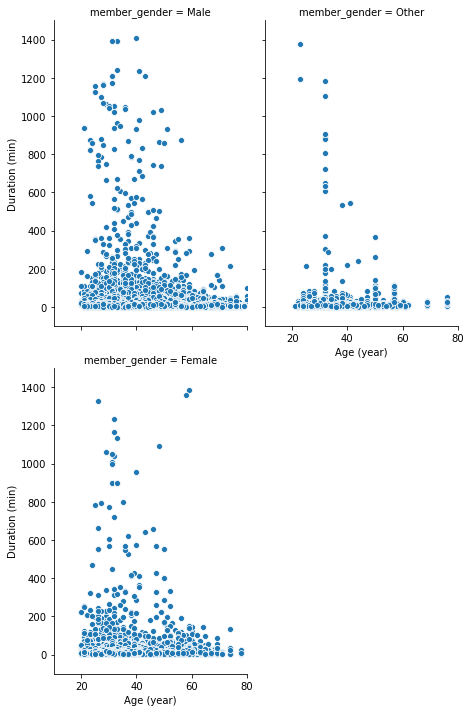

```python
# https://seaborn.pydata.org/generated/seaborn.FacetGrid.html
plt.figure(figsize=[15,10])
g = sns.FacetGrid(data = df, col = 'member_gender', col_wrap = 2, height = 5, aspect =0.65, xlim = [10, 80], ylim = [-100, 1500])
g.map_dataframe(sns.scatterplot, 'age', 'duration_minutes', alpha= None)
g.set_axis_labels('Age (year)', 'Duration (min)')
g.add_legend()
plt.show()
```

# Trip duration on a weekday for each gender type

```python
#df['trip_day'] = df.start_time.dt.strftime('%a')
```

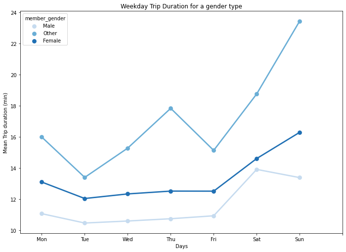

```python
plt.figure(figsize=[11.69, 8.27])
sns.pointplot(data = df, x = 'start_weekday', y = 'duration_minutes', hue = 'member_gender', palette = 'Blues', ci=None)
plt.title('Weekday Trip Duration for a gender type')
plt.ylabel('Mean Trip duration (min)')
plt.xlabel('Days')
plt.xticks(np.arange(0, 7 + 1, 1),weekday_labels)
plt.show()
```

## References

https://www.kaggle.com/chirag02/ford-gobike-data-analysis

https://seaborn.pydata.org/generated/seaborn.FacetGrid.html

https://github.com/meet3012/Ford-GoBike-System-Data-Visualization/blob/master/Data-Exploration-with-Bike-Data.ipynb

https://github.com/adipurnamk/Ford-GoBike-System-Data/blob/master/exploration_fordgobike_2017.ipynb https://github.com/ijdev/Ford-GoBike-System-Data---Data-Analysis

https://mnalmelihi.github.io/z

https://www.citibikenyc.com/system-data

https://rise.readthedocs.io/en/stable/exportpdf.html